# Lecture 4 Factor Analysis Live Demo: 10 Stocks

STAT 24620 = STAT 32900, FINM 34700

Spring 2026

## Goal

In this notebook, we walk through a full factor-analysis workflow using the 10 stocks, downloaded through the `quantmod` package.

## Packages

```r
library(dplyr)
library(tidyr)
library(ggplot2)
library(tibble)
library(purrr)

library(quantmod)
```

## Download the 10 stocks data and data preprocessing

We will get monthly returns (percent %) for 10 stocks (JPMorgan, BOA, WellsFargo, Exxon, Chevron, ConocoPhillips, Apple, Microsoft, NextEra Energy, Duke Energy) from 2010-2026. Each column is stock, and each row is one month.

```r
tickers <- c(
  # Banks
  "JPM", "BAC", "WFC",
  # Energy
  "XOM", "CVX", "COP",
  # Tech
  "AAPL", "MSFT",
  # Utilities
  "NEE", "DUK"
)


getSymbols(tickers, from = "2010-01-01", auto.assign = TRUE)
```

```
 [1] "JPM"  "BAC"  "WFC"  "XOM"  "CVX"  "COP"  "AAPL" "MSFT" "NEE"  "DUK"
```

```r
prices_list <- lapply(tickers, function(tk) {
  Ad(get(tk))
})

prices <- do.call(merge, prices_list)
colnames(prices) <- tickers

returns_list <- lapply(colnames(prices), function(tk) {
  monthlyReturn(prices[, tk], type = "log")
})

returns <- do.call(merge, returns_list)
colnames(returns) <- colnames(prices)

returns <- na.omit(returns)

returns <- returns * 100
```

### Time-series view

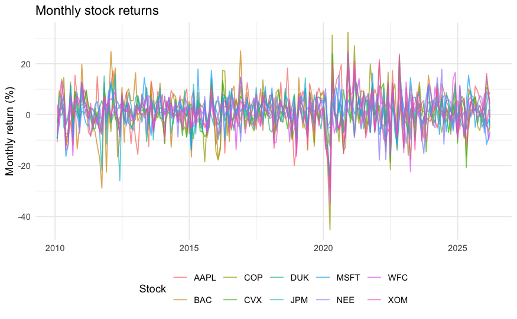

```r
plot_df <- returns %>%
  as.data.frame() %>%
  rownames_to_column(var = "date") %>%
  mutate(date = as.Date(date)) %>%
  pivot_longer(
    cols = -date,
    names_to = "stock",
    values_to = "ret"
  )

ggplot(plot_df, aes(x = date, y = ret, color = stock)) +
  geom_line(alpha = 0.7, linewidth = 0.5) +
  theme_minimal() +
  theme(legend.position = "bottom") +
  labs(
    title = "Monthly stock returns",
    x = NULL,
    y = "Monthly return (%)",
    color = "Stock"
  )
```

### Correlation matrix

Factor analysis is about explaining common dependence, so the correlation matrix is a natural starting point.

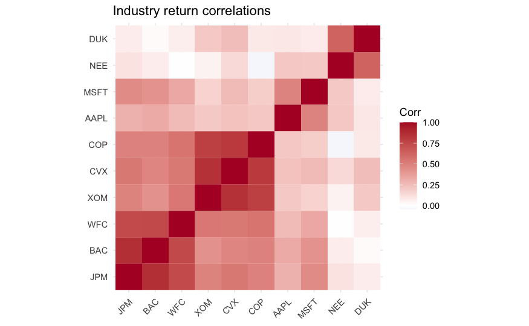

```r
X <- returns

cor_mat <- cor(X)
cor_df <- as.data.frame(as.table(cor_mat))

p_cor <- ggplot(cor_df, aes(Var2, Var1, fill = Freq)) +
  geom_tile() +
  scale_fill_gradient2(low = "#2166AC", mid = "white", high = "#B2182B", midpoint = 0) +
  coord_equal() +
  theme_minimal() +
  labs(title = "Industry return correlations", x = NULL, y = NULL, fill = "Corr") +
  theme(axis.text.x = element_text(angle = 45, hjust = 1))

p_cor
```

We see here that the correlations are mostly positive, and there are clustering structure as expected, indicating the presence of a few latent factors.

### Visualize each stock marginally

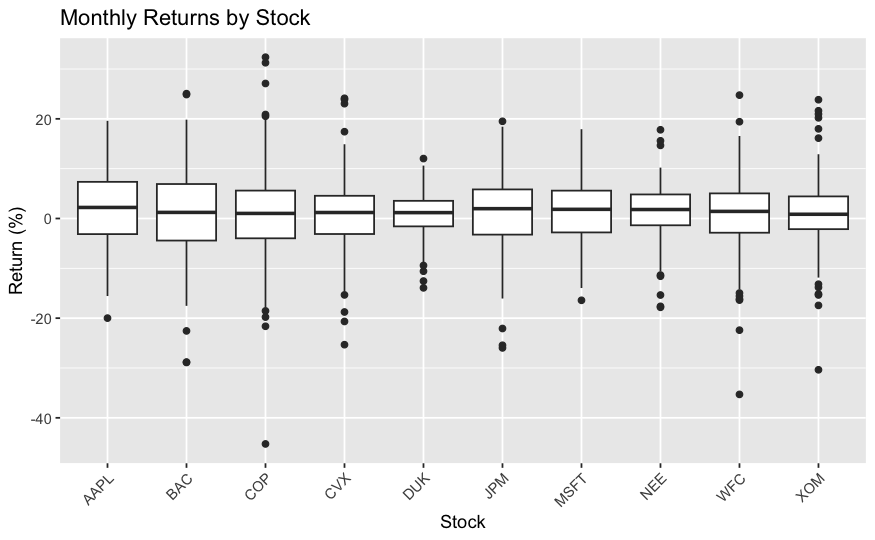

```r
X_long <- as.data.frame(X) %>%
  pivot_longer(cols = everything(),
               names_to = "Stock",
               values_to = "Return")

ggplot(X_long, aes(x = Stock, y = Return)) +
  geom_boxplot() +
  labs(title = "Monthly Returns by Stock",
       y = "Return (%)") +
  theme(axis.text.x = element_text(angle = 45, hjust = 1))
```

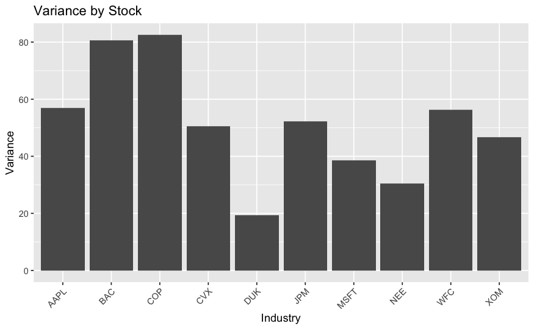

```r
vars <- apply(X, 2, var, na.rm = TRUE)
# variance table
var_df <- data.frame(
  Industry = colnames(X),
  Variance = vars
)

ggplot(var_df, aes(x = Industry, y = Variance)) +
  geom_col() +
  theme(axis.text.x = element_text(angle = 45, hjust = 1)) +
  labs(title = "Variance by Stock")
```

We see moderate marginal volatilities differences across stocks.

## Choosing the number of factors

### Scree plot

We first look at the eigenvalues of the sample correlation matrix.

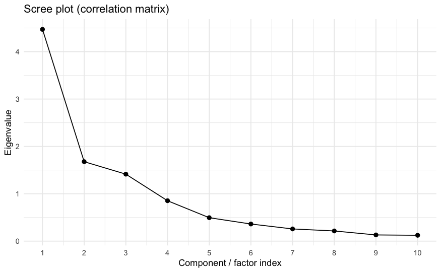

```r
X_std <- scale(X, center = TRUE, scale = TRUE)
pca_full <- prcomp(X_std, center = FALSE, scale. = FALSE)
eig <- pca_full$sdev^2
scree_df <- tibble(component = seq_along(eig), eigenvalue = eig)

ggplot(scree_df, aes(component, eigenvalue)) +
  geom_line() +
  geom_point(size = 2) +
  theme_minimal() +
  scale_x_continuous(breaks = scree_df$component) +
  labs(title = "Scree plot (correlation matrix)",
       x = "Component / factor index",
       y = "Eigenvalue")
```

### Parallel analysis

We compare the observed eigenvalues with those from random noise matrices having the same dimensions.

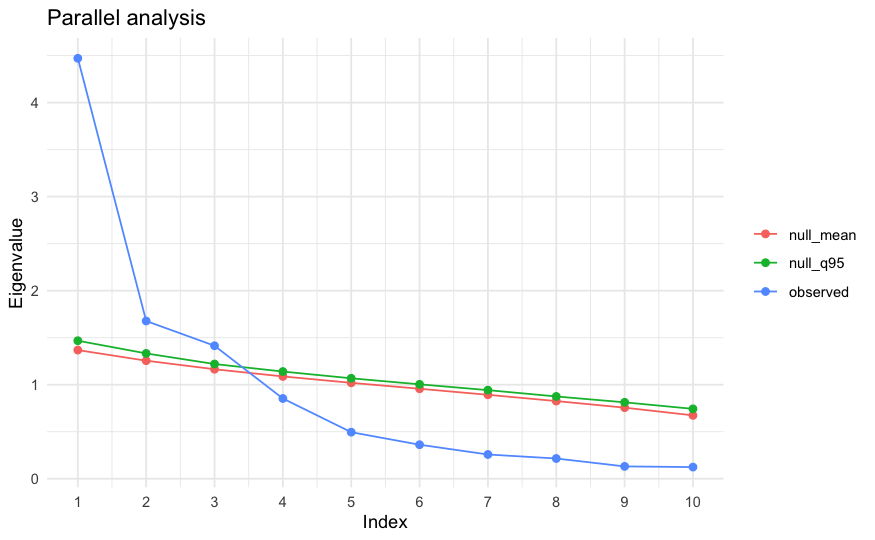

```r
set.seed(24620)
B <- 500
n <- nrow(X_std)
p <- ncol(X_std)

rand_eigs <- replicate(B, {
  X_rand <- matrix(rnorm(n * p), nrow = n, ncol = p)
  eigen(cor(X_rand), symmetric = TRUE, only.values = TRUE)$values
})

pa_mean <- rowMeans(rand_eigs)
pa_q95 <- apply(rand_eigs, 1, quantile, probs = 0.95)

pa_df <- tibble(
  k = seq_len(p),
  observed = eig,
  null_mean = pa_mean,
  null_q95 = pa_q95
) %>%
  pivot_longer(-k, names_to = "series", values_to = "value")

ggplot(pa_df, aes(k, value, color = series)) +
  geom_line() +
  geom_point(size = 1.8) +
  theme_minimal() +
  scale_x_continuous(breaks = seq_len(p)) +
  labs(title = "Parallel analysis", x = "Index", y = "Eigenvalue", color = NULL)
```

A simple rule is to keep factors whose observed eigenvalues exceed the null benchmark.

```r
pa_m <- sum(eig > pa_q95)
pa_m
```

```
[1] 3
```

PA suggests 3 factors.

### Fit several FA models

We fit several candidate models and compare their residual fit. Here we use `factanal()` on the data matrix.

```r
fit_grid <- function(X, m_values = 1:5) {
  map(m_values, ~ factanal(X, factors = .x, rotation = "none", scores = "regression")) %>%
    setNames(paste0("m", m_values))
}

fa_fits <- fit_grid(X, m_values = 1:5)
fa_fits$m2
```

```
Call:
factanal(x = X, factors = .x, scores = "regression", rotation = "none")

Uniquenesses:
  JPM   BAC   WFC   XOM   CVX   COP  AAPL  MSFT   NEE   DUK
0.158 0.119 0.341 0.169 0.121 0.251 0.878 0.776 0.991 0.943

Loadings:
     Factor1 Factor2
JPM   0.826   0.400
BAC   0.807   0.480
WFC   0.776   0.240
XOM   0.797  -0.441
CVX   0.841  -0.415
COP   0.796  -0.340
AAPL  0.325   0.129
MSFT  0.394   0.262
NEE
DUK   0.151  -0.186

               Factor1 Factor2
SS loadings      4.203   1.050
Proportion Var   0.420   0.105
Cumulative Var   0.420   0.525

Test of the hypothesis that 2 factors are sufficient.
The chi square statistic is 182.2 on 26 degrees of freedom.
The p-value is 2.14e-25
```

### Residual correlation diagnostics

After fitting FA, we compare the observed covariance (or correlation) with the model-implied one:
$$\hat \Sigma = \hat L \hat L^\top + \hat\Psi.$$

To assess model fit, we examine the residual matrix:
$$\text{Residual} = R - \hat R.$$
We convert covariance matrix to correlation matrix using the `cov2cor` function. We summarize residual fit using the off-diagonal RMSR.

```r
fa_residual_cor <- function(fit, S) {
  L <- unclass(fit$loadings)
  Psi <- diag(fit$uniquenesses)
  Sigma_hat <- L %*% t(L) + Psi

  R_obs <- cov2cor(S)
  R_hat <- cov2cor(Sigma_hat)

  R_obs - R_hat
}

rmsr_offdiag <- function(M) {
  idx <- row(M) < col(M)
  sqrt(mean(M[idx]^2))
}

diag_tbl <- imap_dfr(fa_fits, function(fit, nm) {
  resid <- fa_residual_cor(fit, cor(X_std))
  tibble(
    model = nm,
    m = fit$factors,
    rmsr = rmsr_offdiag(resid),
    max_abs_resid = max(abs(resid[row(resid) < col(resid)]))
  )
})

diag_tbl
```

| model | m | rmsr | max_abs_resid |
| --- | --- | --- | --- |
| m1 | 1 | 0.171524 | 0.60944 |
| m2 | 2 | 0.114684 | 0.61156 |
| m3 | 3 | 0.046660 | 0.29077 |
| m4 | 4 | 0.013147 | 0.03836 |
| m5 | 5 | 0.006037 | 0.01640 |

## Choose a working model

Let’s first use 3 factors for FA.

### Inspect the chosen FA model

The R output also shows you the p-value from likelihood-ratio test, testing whether having these factors are enough assuming data coming from a Gaussian factor analysis model.

```r
m_star <- 3
fa_raw <- factanal(X, factors = m_star, rotation = "none", scores = "regression")
fa_rot <- factanal(X, factors = m_star, rotation = "varimax", scores = "regression")

fa_rot
```

```
Call:
factanal(x = X, factors = m_star, scores = "regression", rotation = "varimax")

Uniquenesses:
  JPM   BAC   WFC   XOM   CVX   COP  AAPL  MSFT   NEE   DUK
0.156 0.120 0.333 0.172 0.113 0.228 0.844 0.744 0.069 0.535

Loadings:
     Factor1 Factor2 Factor3
JPM   0.864   0.313
BAC   0.903   0.251
WFC   0.706   0.403
XOM   0.240   0.874
CVX   0.293   0.879   0.171
COP   0.302   0.825
AAPL  0.335   0.115   0.175
MSFT  0.477           0.149
NEE   0.141           0.952
DUK           0.146   0.666

               Factor1 Factor2 Factor3
SS loadings      2.653   2.585   1.447
Proportion Var   0.265   0.259   0.145
Cumulative Var   0.265   0.524   0.669

Test of the hypothesis that 3 factors are sufficient.
The chi square statistic is 49.49 on 18 degrees of freedom.
The p-value is 9.01e-05
```

### Uniquenesses and communalities

```r
fa_summary <- tibble(
  industry = names(fa_rot$uniquenesses),
  uniqueness = as.numeric(fa_rot$uniquenesses),
  communality = 1 - uniqueness
) %>%
  arrange(desc(communality))

fa_summary
```

| industry | uniqueness | communality |
| --- | --- | --- |
| NEE | 0.06864 | 0.9314 |
| CVX | 0.11270 | 0.8873 |
| BAC | 0.12037 | 0.8796 |
| JPM | 0.15649 | 0.8435 |
| XOM | 0.17233 | 0.8277 |
| COP | 0.22802 | 0.7720 |
| WFC | 0.33275 | 0.6672 |
| DUK | 0.53467 | 0.4653 |
| MSFT | 0.74438 | 0.2556 |
| AAPL | 0.84407 | 0.1559 |

Interpretation:

- A **high communality** means that the industry’s return variation is largely explained by the common factors.
- A **high uniqueness** means that the industry retains a lot of idiosyncratic variation after accounting for common factors.

We can see that `MSFT` and `AAPL` still have large uniqueness, also the p-value is still very small. So maybe we actually need more factors, which is consistent with our intuition.

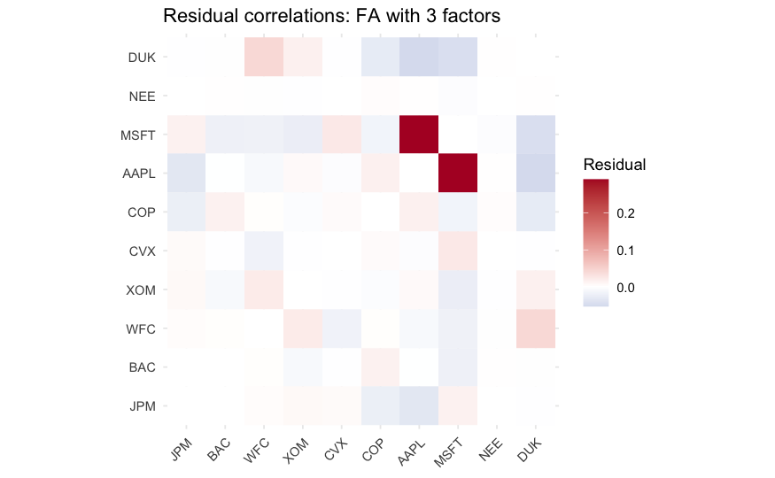

```r
resid_mat <- fa_residual_cor(fa_rot, cor(X_std))
resid_df <- as.data.frame(as.table(resid_mat))

ggplot(resid_df, aes(Var2, Var1, fill = Freq)) +
  geom_tile() +
  scale_fill_gradient2(low = "#2166AC", mid = "white", high = "#B2182B", midpoint = 0) +
  coord_equal() +
  theme_minimal() +
  labs(title = paste("Residual correlations: FA with", m_star, "factors"),
       x = NULL, y = NULL, fill = "Residual") +
  theme(axis.text.x = element_text(angle = 45, hjust = 1))
```

This plot helps decide whether the chosen factor model is still missing systematic structure. We see that `MSFT` and `AAPL` still have strong residual correlation, that is evidence that `m` may still be too small or that the factor model is not capturing the dependence pattern well.

## Revised factor model: adding a fourth factor

```r
m_star <- m_star + 1
fa_raw <- factanal(X, factors = m_star, rotation = "none", scores = "regression")
fa_rot <- factanal(X, factors = m_star, rotation = "varimax", scores = "regression")

fa_rot
```

```
Call:
factanal(x = X, factors = m_star, scores = "regression", rotation = "varimax")

Uniquenesses:
  JPM   BAC   WFC   XOM   CVX   COP  AAPL  MSFT   NEE   DUK
0.166 0.104 0.333 0.173 0.109 0.229 0.732 0.005 0.037 0.545

Loadings:
     Factor1 Factor2 Factor3 Factor4
JPM   0.304   0.817           0.267
BAC   0.236   0.888           0.228
WFC   0.393   0.693           0.174
XOM   0.872   0.238
CVX   0.879   0.264   0.164   0.146
COP   0.819   0.307
AAPL  0.113   0.203   0.138   0.442
MSFT          0.211           0.972
NEE                   0.966   0.153
DUK   0.157           0.654

               Factor1 Factor2 Factor3 Factor4
SS loadings      2.551   2.245   1.420   1.350
Proportion Var   0.255   0.225   0.142   0.135
Cumulative Var   0.255   0.480   0.622   0.757

Test of the hypothesis that 4 factors are sufficient.
The chi square statistic is 16.58 on 11 degrees of freedom.
The p-value is 0.121
```

```r
fa_summary <- tibble(
  industry = names(fa_rot$uniquenesses),
  uniqueness = as.numeric(fa_rot$uniquenesses),
  communality = 1 - uniqueness
) %>%
  arrange(desc(communality))

fa_summary
```

| industry | uniqueness | communality |
| --- | --- | --- |
| MSFT | 0.00500 | 0.9950 |
| NEE | 0.03726 | 0.9627 |
| BAC | 0.10415 | 0.8958 |
| CVX | 0.10918 | 0.8908 |
| JPM | 0.16638 | 0.8336 |
| XOM | 0.17251 | 0.8275 |
| COP | 0.22933 | 0.7707 |
| WFC | 0.33325 | 0.6667 |
| DUK | 0.54486 | 0.4551 |
| AAPL | 0.73189 | 0.2681 |

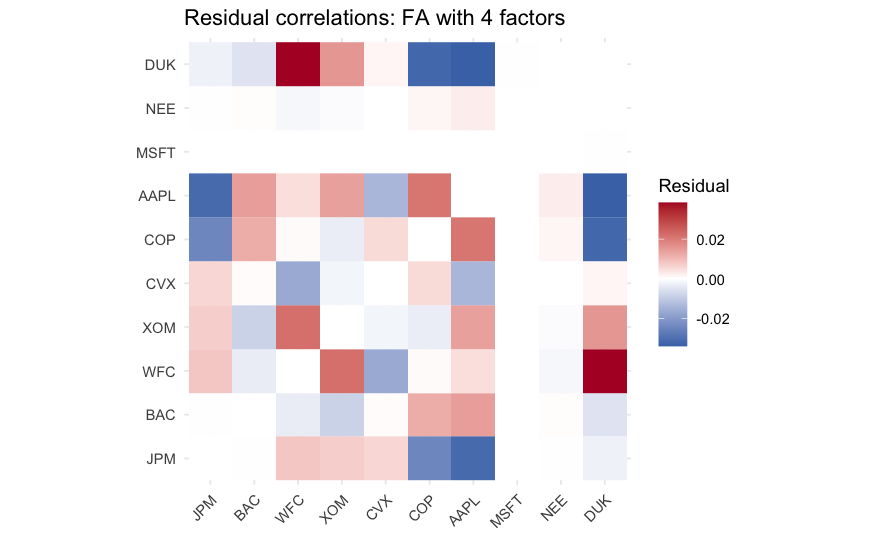

```r
resid_mat <- fa_residual_cor(fa_rot, cor(X_std))
resid_df <- as.data.frame(as.table(resid_mat))

ggplot(resid_df, aes(Var2, Var1, fill = Freq)) +
  geom_tile() +
  scale_fill_gradient2(low = "#2166AC", mid = "white", high = "#B2182B", midpoint = 0) +
  coord_equal() +
  theme_minimal() +
  labs(title = paste("Residual correlations: FA with", m_star, "factors"),
       x = NULL, y = NULL, fill = "Residual") +
  theme(axis.text.x = element_text(angle = 45, hjust = 1))
```

The fourth factor seems to mainly explain `MSFT`, but the test does become insignificant, and there are no remaining large correlations left. So we should still include this factor.

## Rotation: unrotated vs varimax loadings

```r
loadings_to_df <- function(fit, label) {
  as.data.frame(unclass(fit$loadings)) %>%
    tibble::rownames_to_column("stock") %>%
    pivot_longer(-stock, names_to = "factor", values_to = "loading") %>%
    mutate(method = label)
}

load_df <- bind_rows(
  loadings_to_df(fa_raw, "Unrotated FA"),
  loadings_to_df(fa_rot, "Varimax FA")
)

load_df$stock <- factor(load_df$stock, levels = rownames(fa_raw$loadings))
```

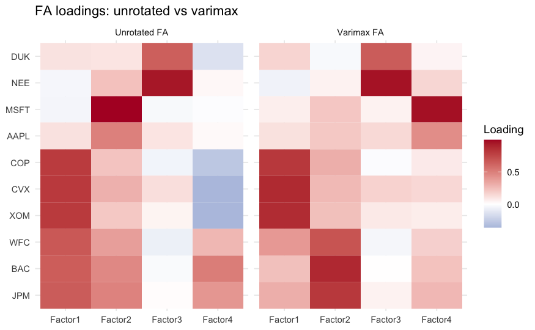

```r
ggplot(load_df, aes(factor, stock, fill = loading)) +
  geom_tile() +
  scale_fill_gradient2(low = "#2166AC", mid = "white", high = "#B2182B", midpoint = 0) +
  facet_wrap(~ method, nrow = 1) +
  theme_minimal() +
  labs(title = "FA loadings: unrotated vs varimax",
       x = NULL, y = NULL, fill = "Loading")
```

In practice, the unrotated loadings often look diffuse: many stocks may load moderately on multiple factors. After varimax rotation, the pattern is usually easier to narrate because some factors become more concentrated on particular groups of stocks.

- Factor 1: Energy
- Factor 2: Bank
- Factor 3: Utility
- Factor 4: High Tech

## Factor scores

The regression scores provide estimated latent-factor realizations over time.

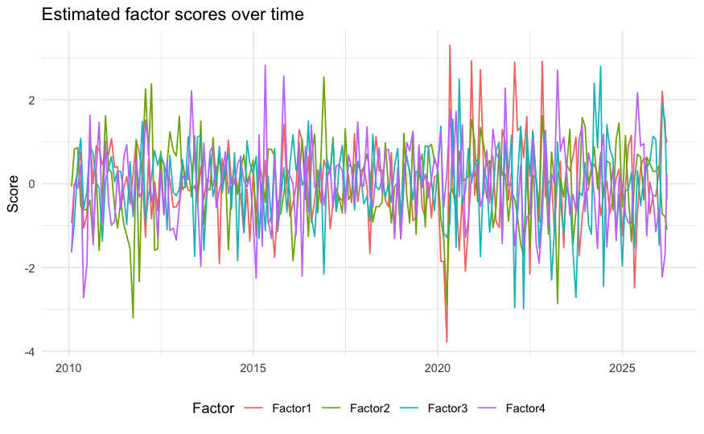

```r
Fhat <- fa_rot$scores %>%
      as.data.frame() %>%
      rownames_to_column(var = "date") %>%
      mutate(date = as.Date(date))


Fhat_long <- Fhat %>%
  pivot_longer(-date, names_to = "factor", values_to = "score")

ggplot(Fhat_long, aes(date, score, color = factor)) +
  geom_line(linewidth = 0.5) +
  theme_minimal() +
  theme(legend.position = "bottom") +
  labs(title = "Estimated factor scores over time",
       x = NULL, y = "Score", color = "Factor")
```

## Comparison with PCA

We now compare FA with PCA on the standardized matrix.

```r
pca <- prcomp(X_std, center = FALSE, scale. = FALSE)
round(pca$rotation[, 1:m_star], 3)
```

```
       PC1    PC2    PC3    PC4
JPM  0.395 -0.061  0.228 -0.359
BAC  0.383 -0.092  0.273 -0.360
WFC  0.384 -0.140  0.115 -0.306
XOM  0.373 -0.075 -0.391  0.211
CVX  0.393 -0.008 -0.351  0.193
COP  0.375 -0.168 -0.319  0.224
AAPL 0.208  0.226  0.393  0.616
MSFT 0.238  0.195  0.487  0.266
NEE  0.078  0.683 -0.045 -0.165
DUK  0.098  0.616 -0.297 -0.196
```

### PCA vs FA loadings heatmap

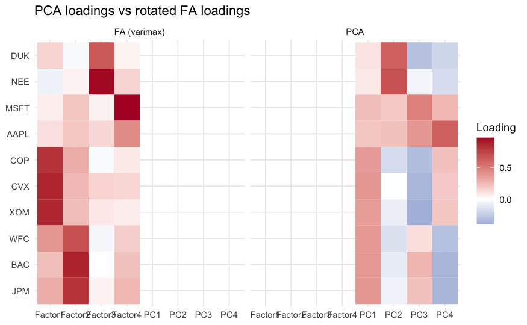

```r
pca_load_df <- as.data.frame(pca$rotation[, 1:m_star, drop = FALSE]) %>%
  tibble::rownames_to_column("stock") %>%
  pivot_longer(-stock, names_to = "factor", values_to = "loading") %>%
  mutate(method = "PCA")

fa_rot_df <- loadings_to_df(fa_rot, "FA (varimax)")
plot_load_compare <- bind_rows(pca_load_df, fa_rot_df)
plot_load_compare$stock <- factor(plot_load_compare$stock, levels = rownames(fa_rot$loadings))

ggplot(plot_load_compare, aes(factor, stock, fill = loading)) +
  geom_tile() +
  scale_fill_gradient2(low = "#2166AC", mid = "white", high = "#B2182B", midpoint = 0) +
  facet_wrap(~ method, nrow = 1) +
  theme_minimal() +
  labs(title = "PCA loadings vs rotated FA loadings",
       x = NULL, y = NULL, fill = "Loading")
```

PCA loadings describe orthogonal variance-maximizing directions, while FA loadings describe how observed variables depend on latent common factors plus uniquenesses. After rotation, FA gives clearer clustering structure of the variables. In contrast, PCA learns the shared market effect as the first PC.

## Key takeaways

- FA is a model for the covariance/correlation structure, not just a data-reduction device.
- The number of factors should be chosen using both **eigenvalue diagnostics** and **post-fit residual checks**.
- Rotation can be helpful for interpretation.
- PCA and FA may look similar in practice, but their objectives are different.